# Miniproject: Image Classification

#### Exercise 6.1.

Design a convolutional neural network and train it without using explicit regularizers.

```python
# Images must be in 4 dimensions, we must reshape
x_fashion_mnist_train_with_channel = add_channel_to_images(x_fashion_mnist_train)
x_fashion_mnist_val_with_channel = add_channel_to_images(x_fashion_mnist_val)

print("Reshaped train data from {0} to {1}".format(x_fashion_mnist_train.shape, x_fashion_mnist_train_with_channel.shape))
print("Reshaped validation data from {0} to {1}".format(x_fashion_mnist_val.shape, x_fashion_mnist_val_with_channel.shape))
```

```
Reshaped train data from (60000, 28, 28) to (60000, 28, 28, 1)
Reshaped validation data from (10000, 28, 28) to (10000, 28, 28, 1)
```

```python
input_shape = x_fashion_mnist_train_with_channel[0].shape
kernel_l2=0
bias_l2=0
dropout=0

model = get_convolutional_model(
    input_shape=input_shape,
    output_length=classes_nb_fash_mnist,
    kernel_l2=kernel_l2,
    bias_l2=bias_l2,
    dropout=dropout,
    batch_normalization=False
)
```

```python
history_naive = fit_custom(
    exercise_name="ex_6.1_l2_{0}_bias_{1}_dropout_{2}".format(kernel_l2, bias_l2, dropout),
    model=model,
    x=x_fashion_mnist_train_with_channel,
    y=y_fashion_mnist_train_1hot,
    validation_data=(x_fashion_mnist_val_with_channel, y_fashion_mnist_val_1hot),
    batch_size=128,
    epochs=50,
    callbacks=get_callbacks(early_stop=True),
    verbose=1)
```

```
Loading save/ex_6.1_l2_0_bias_0_dropout_0_history.npy
```

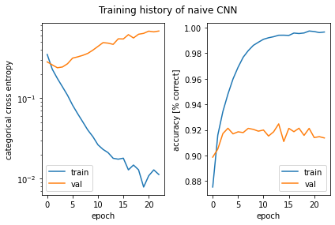

```python
plot_history_custom(history_naive, "Training history of naive CNN");
```

```python
print("For the CNN without regularization, the best validation accuracy is {0}.".format(round(max(history_naive["val_accuracy"]), 2)))
```

```
For the CNN without regularization, the best validation accuracy is 0.92.
```

#### Exercise 6.2.

Try to improve the best validation scores of the model by experiment with batch_normalization layers, dropout layers and l2-regularization on weights (kernels) and biases

```python
kernel_l2=1e-4
bias_l2=1e-4
dropout=0.2

model = get_convolutional_model(
    input_shape=input_shape,
    output_length=classes_nb_fash_mnist,
    kernel_l2=kernel_l2,
    bias_l2=bias_l2,
    dropout=dropout,
    batch_normalization=True
)
```

```python
history_tuned = fit_custom(
    exercise_name="ex_6.2_l2_{0}_bias_{1}_dropout_{2}".format(kernel_l2, bias_l2, dropout),
    model=model,
    x=x_fashion_mnist_train_with_channel,
    y=y_fashion_mnist_train_1hot,
    validation_data=(x_fashion_mnist_val_with_channel, y_fashion_mnist_val_1hot),
    batch_size=128,
    epochs=50,
    callbacks=get_callbacks(early_stop=True),
    verbose=1)
```

```
Loading save/ex_6.2_l2_0.0001_bias_0.0001_dropout_0.2_history.npy
```

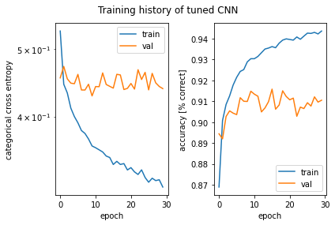

```python
plot_history_custom(history_tuned, "Training history of tuned CNN");
```

```python
print("For the tuned CNN, the best validation accuracy is {0}.".format(round(max(history_tuned["val_accuracy"]), 2)))
```

```
For the tuned CNN, the best validation accuracy is 0.92.
```

#### Exercise 6.3.

After you have found good settings, plot the learning curves for both models, naive (=no tricks/regularization) and tuned (=tricks + regularized) together in a comparison plot.

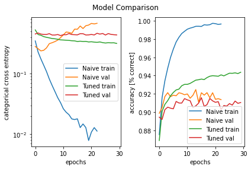

```python
comparison_plot_custom(history_naive, history_tuned, "Naive", "Tuned", "Model Comparison");
```

Remark: in the plot, we can see that the validation loss of the naive model performs better than the tuned model. It means that the regularization parameters are not optimal and should be fine-tuned. We tried some differents values but didn't find a better one, so we should keep trying.

#### Exercise 6.4

How does the CNN performance compare to the so far best performing (deep) neural network model? (2 pts)

**Answer to Question 4**: The best performing deep neural network achieves a validation accuracy of 89%, and the best CNN 92%. So the CNN performs better. The naive CNN converges very fast to an optimum loss (around 2 epochs) what makes it much faster than neural network models.